# Solutions for the Short-Term Economic Impacts of Marine Reserves

Dan Ovando, Dawn Dougherty, Jono Wilson

July 9, 2015

# Note

# Abstract

Well-managed fisheries are critical for supporting healthy ocean ecosystems, coastal livelihoods, and food security for millions of people. Many communities lack the resources to implement effective fisheries management. No-take marine reserves are a relatively simple tool to conserve biodiversity and provide fishery benefits. While the biological and long-term economic effects of reserves on fisheries have been well studied, the short-term economic impacts of establishing marine reserves are rarely considered. In this paper we simulate fisheries for six species commonly caught in coastal fisheries in order to demonstrate the time required for a no-take reserve to provide a net improvement in the economic well-being of a fishing community. Our results show that while conservation benefits accrue rapidly, more than a decade is often required to provide net fisheries benefits, even under circumstances favorable for reserves. We explore a suite of strategies for mitigating these short-term economic losses, including flexible reserve designs, loans, and value increases. Our results indicate that reserves may struggle to provide short-term economic benefits to artisnal fisheries, and value increases show the most potential for offsetting these losses. Our findings provide mechanisms for improving the communication and use of no-take marine reserves as tools for fisheries management and conservation.

# Introduction

More than 260 million people across the globe earn their livelihood in fishing related industries (Teh *et al.* 2014). Fish is a primary source of protein to over one billion people (FAO 2011). Yet the sustainability of the fishing industry and the potential for wild capture fisheries to indefinitely feed a growing population is dependent on the implementation and enforcement of effective systems of governance and management. No-take marine reserves (hereafter reserves), areas set off-limits to fishing, are a widely used tool for protecting fish populations and are known to provide key conservation benefits that can improve ecosystem services to coastal environments. Conservation benefits of marine reserves include the maintenance of spatial population structure of fish stocks (Berkeley *et al.* 2004; White *et al.* 2008; Rassweiler *et al.* 2012), protection of essential fish habitat, increased species diversity and fish biomass (Lester *et al.* 2009), a hedge against changes in environmental conditions (Stefansson and Rosenberg 2005; Costello and Polasky 2008), an effective means of protecting spatially complex marine populations (White *et al.* 2008; Rassweiler *et al.* 2012), and can serve as reference areas to set local management regulations and disentangle the effects of fishing from environmental variability (Wilson *et al.* 2013). Enhanced biological production inside reserves can benefit adjacent fisheries through adult spillover (Roberts and Polunin 1991; Allison *et al.* 1998; McClanahan and Mangi 2008) and larval export (Cudney-Bueno *et al.* 2009; Pelc *et al.* 2010), especially in situations where the size of the reserve is larger than the adult home range size, and smaller than the scale of larval dispersal (Gerber *et al.* 2003).

In some cases marine reserves can serve as a mechanism for simultaneously achieving conservation outcomes and improving the productivity of fisheries (Hilborn *et al.* 2006; Gaines *et al.* 2010). The case for using reserves for both conservation and fishery management is often made in the context of developing world fisheries, which may have little capacity to perform more complex fishery management practices (such as quotas, size limits, or effort restrictions) (Holland and Brazee 1996). In fact, reserves have a long history as fishery management tools in many island nations (Johannes 1978, 2002). However, the ability of marine reserves to provide fishery benefits is dependent on a suite of factors, including the size of reserve relative to the home range size of the species, the dispersal potential, geographic extent of the stock, as well as the status of the fishery prior to implementation of reserves (Sanchirico and Wilen 2001; Smith and Wilen 2003; Sanchirico *et al.* 2006; Costello and Polasky 2008; White *et al.* 2008; Rassweiler *et al.* 2012). Moreover, the implementation of marine reserves necessarily reduces the spatial extent of the fishery, often limiting take in prime fishing grounds and concentrating effort into areas where fishing is still allowed (Halpern *et al.* 2004).

The potential and challenges of utilizing reserves as fishery management tools have been well studied (Hilborn *et al.* 2004), though it is worth noting that the vast majority of this work is simulation based, and little empirical evidence of the fishery impacts of reserves is available (see Fletcher *et al.* 2014 for an empirical paper that found no evidence of enhanced fishery production from the Great Barrier Reef marine reserve). However, there is a critical gap in the understanding how the economic effects of reserves on fisheries play out over time. Nearly all of the published research on the topic has considered the long-term (or equilibrium) economic impacts of implementing a marine reserve (note that for this paper, the we refer solely to fishing when we consider economic impacts).

While the long-term impacts are critical to understanding the interactions between reserves and fisheries, from the perspective of fishing communities the short-term impacts may be of much greater consequence. Depending on the time horizon that a community is able or willing to consider, a reserve that provides long-term fishery benefits may provide no practical benefit to today’s fishers and decision makers. Alternatively, even in conditions in which a community will perceive benefits in the future, they may have to endure years of reduced fishing income and food until those benefits arrive.These short-term consequences of reserves can have profound implications on the financial health and food security of fishing communities, affecting local support and buy in for enforcement policies, trust in management and supporting organizations, and ultimately the sustainability of the fishery itself.

Brown et al. (2014) provides an important contribution to our understanding of the short-term impacts of marine reserves. They illustrate that there are often important tradeoffs between short-term and long-term economic fishing benefits from reserves, and that alternative strategies for designing those reserves (how large they are and how that size changes over time) can affect the short-term economic effects of a reserve. Brown et al. (2014) launches an important discussion on the ways in which we might choose to design reserves in order to provide fishery benefits, and the ways in which the consequences of those choices can be communicated to fishing communities. In particular, they point out that reserves designed around long-term benefits have substantial short-term costs. Our paper builds on this work by focusing on potential solutions to the trade-offs identified by Brown et al. (2014).

One potential strategy for minimizing economic impacts is to optimize the size and implementation of a reserve in order to maximize a community’s benefit. Alternatively financial mechanisms such as loans or price increases could be used to offset losses incurred from a reserve. We analyze the potential of design and financial instruments to offset economic losses by using a simulated developing world fishery targeting a variety of typical tropical reef species. We focus on artisanal fisheries such as these, since small-scale fisheries throughout the developing tropics are often targeted as sites for reserve based management. We find that reserves may struggle to provide net fishing benefits at a time scale that is of value to fishing communities for many common reef associated fish species, and financial mechanisms may be needed to offset these losses.

# Methods

## Operating Model

We analyzed 6 different species, intended to capture a range of life-history traits of species often targeted by tropical developing country fisheries. Our model is single species, age-structured, and is closed to larval and adult emigration and immigration. The spatial configuration of the fishery includes 100 unique patches with wrapped edges connected by larval and adult movement. The model tracks stock numbers, biomass, and fishery yields over time. This structure best represents a small-scale fishing community on an island or isolated stretch of coastline. Life history values were drawn from stock assessments where possible, in order to help ensure reliable and consistent values(Table.1). The recruitment model (or the functional form of the density dependence relationship) was selected from the possible structures outlined in Babcock & MacCall (2011) using expert judgement. The *Range* parameter scales the number of patches moved by adults in a time step, with 100% indicating total mixing and 0% a completely sedentary species.

Life history values used. m is natural mortality, Linf, k, and t0 are the Von Bertalanffy growth parameters, Age/Length Ma50 are the respective age or length at which the 50% of the individuals have reached sexual maturity, h is steepness, and the roman numeral under “Density Dependence” corresponds with the density dependence form from Babcock & MacCall 2011 that was used. Values with * were assumed

| Species | Range | m | k | Linf | t0 | AgeMa50 | LengthMa50 | h | Recruitment Model | Source |
| --- | --- | --- | --- | --- | --- | --- | --- | --- | --- | --- |
| Yellowtail Snapper | 20%* | 0.19 | 0.13 | 618.0 | -3.13 | 1.7 | 232.4 | 0.70 | III* | Hop et al. 2012 |
| Red Grouper | 20%* | 0.14 | 0.16 | 854.0 | -0.19 | 3.0 | 341.0 | 0.84 | II* | SEDAR 2009 |
| Silver Trevally | 60%* | 0.10 | 0.05 | 631.6 | -0.65 | NA | 190.0 | 0.75 | III* | Rowling & Raines 2000; Tuck 2007 |
| Blacknose Shark | 40%* | 0.23 | 0.32 | 1012.0 | -1.70 | 4.5 | NA | 0.35 | I* | SEDAR 2011 |
| Bumphead Parrotfish | 20%* | 0.28 | 0.12 | 1144.5 | 0.00 | 8.0 | 550.0 | 0.70 | II* | Kobayashi et al. 2011 |
| Red Throat Emperor | 40%* | 0.51 | 0.37 | 459.1 | -0.36 | 2.0 | 280.0 | 0.70 | III* | Leigh et al. 2006 |

The number of fish in patch i at age a at the beginning of year t+1 is

1. $N_{i,a,t+1} = R_{i,t+1}$ if *a = 0*
2. $N_{i,a,t+1} = N_{i,a-1,t}e^{-M-F_{i,t}\upsilon_{a-1}}$ if $1 \leq a < x$
3. $N_{i,a,t+1} = N_{i,x-1,t}e^{-M-F_{i,t}\upsilon_{x-1}} + N_{i,x,t}e^{-M-F_{i,t}\upsilon_{x}}$ if $a = x$

where *R<sub>i,t</sub>*is the recruitment in patch *i* in year *t*, *F<sub>i,t</sub>* is the instantaneous fishing mortality in patch *i* in year *t*, $\upsilon_{a}$ is the selectivity of the fishing gear for a fish at age *a* (which we assume to be 1 for all ages), *M* is the instantaneous natural mortality, and *x* is the maximum age recorded in the model (the plus group). This model assumes that the biological parameters of each species are homogeneous across space and time.

The simulations begin at an unfished equilibrium using a specified unfished initial recruitment in each patch *i*, *R<sub>i,0</sub>* such that

4. $N_{i,a} = R_{i,0}$ if *a = 0*
5. $N_{i,a} = N_{i,a-1}e^{-M}$ if $1 \leq a < x$
6. $N_{i,a} = \frac{N_{i,x-1}e^{-M}}{1-e^{-M}}$ if $a = x$

The population is then fished down at a specified open access harvest rate in both patches to equilibrium conditions. We set this rate such that biomass relative to biomass at maximum sustainable yield (B/B<sub>MSY</sub>) is equal to 0.25 at equilibrium, representing an overfished fishery. We chose this level to simulate a highly overfished fishery with little to no capacity for management, and to ensure that the reserve had high potential to benefit the fishery in the long-term. Starting from this overfished state provides an optimistic estimation of the potential benefits of reserve formation.

The average length (*l<sub>a</sub>*) of fish in each age class is calculated using a von Bertalanffy growth equation

7. $l_{a} = L_{inf}(1-e^{-k(t-t_{0})})$

and then converted to average weight (*w<sub>a</sub>*) using:

8. $w_{a}=b_{1}l_{a}^{b_{2}}$

We assume habitat quality to be the same in all patches. Adult movement at each time step among the 100 patches is then calculated using a Gaussian dispersal kernel

9. $p_{i,j}=e^{\frac{-d_{i,j}^{2} }{2\sigma_{A}^{2}}}$

where *p<sub>i,j</sub>* is the proportion of fish moving from area *i* to area *j*, and *d<sub>i,j</sub>* is the distance between area *i* and area *j*. The model parameter $\sigma_{A}$ defines the movement range for the species, and is scaled by the *Range* parameter. We wrap movement in order to remove edge effects. The relative proportions are then normalized so that the total proportion of fish moving from area *i* to any area sum to one. The number of fish in each age group one and older after movement are then

10. $N_{i,a,t} = \sum^{100}_{j=1} N_{j,a,t}p_{i,j}$

To calculate recruitment each year in each patch we use the recruitment models described in Babcock & MacCall (2011), in order to allow the nature of density dependence to vary among species (for example, pre or post settlement density dependence).

## Fishery Dynamics

The catch in each patch at each time step is calculated as

11. $Y_{i,t} = \sum_{a}(N_{i,a,t}e^{-F_{i,t}\upsilon_{a}})$

We assume a closed population of fishers, where the number of fishers does not change with the implementation of a reserve (no emigration or immigration of boats), such that the effort from the reserve area is displaced to the fished area. This is intended to reflect a subsistence style fishery, with few alternative livelihoods besides fishing. Fishing effort is scaled by the relative commercial biomass,$\bar{B}_{i}$, in each patch where

12. $\bar{B}_{i}= \frac{B_{i}}{\sum_{i}B_{i}}$
13. $F_{i,t}=F_{i,pNTZ}(1+P_{NTZ})\bar{B}_{i,t}$

Where *F<sub>pNTZ</sub>* is the total possible instantaneous fishing pressure in the patch *i* before the implementation of the reserve, and *P<sub>NTZ</sub>* is the fraction of patches that are in a reserve.

## Reserve Implementation

We simulate a series of reserve implementation scenarios using the above operating model and fleet dynamics. A given scenario is defined by an terminal reserve size (% of area in a reserve), an “intercept” (% of the area in a reserve in year 1), and a “slope” (% of run years at which the reserve reaches terminal size). In effect then we allow the final size, initial size, and rate at which the reserve reaches its final size to vary. We apply a fine-scale grid of factorial combinations of reserve size, intercept, and slope to each of the 6 species included in this paper, providing an outline of the potential outcomes of reserve implementation. Reserves are applied as a continuous block in the center of the system (alternative configurations such as a reserve on the left or right side of the system do not alter resutls).

## Metrics

Throughout each scenario we keep track of live biomass of fish in the water and fishery yields over time. Net present balance (NPB) is our primary metric of performance, where NPB represents the present value of the cumulative yield benefits of a given reserve strategy relative to the status quo, calculated as

14. $NPB_{s} = \sum^{T}_{t=0} \frac{Y_{s,t}-Y_{q}}{(1+r)^{t}}$

for any given species, where *t* is time, *Y* represents fishing yields, *s* is reserve implementation strategy, *q* is the status quo, *r* is the economic discount rate, and *T* is a specified number of years after reserve implementation in which *NPB* is calculated and compared across scenarios and species. We calculate the year at which NPB surpasses zero (increased benefits have compensated for short-term losses). NPB is an important output, since it reflects the benefits that a community today perceives they will receive over time from a given reserve strategy, relative to the benefits they would have received without the reserve. So a positive NPB implies that the community perceives a net improvement in catches resulting from the reserve, a negative a net loss in catches over time resulting from the reserve. Alternatively, the yield balance, the difference between catches with and without a given reserve in year *t*, while important and a commonly presented metric, may not be as meaningful to a community. For example, a one ton increase in catches, relative to the status quo, that takes ten years to develop is of little value if 1,000 tons have been lost in years 1 through 9.

To illustrate this concept, consider an overfished fishery at equilibrium, such as the one simulated here. In year 1, we implement a marine reserve of an arbitraty size (Fig.1). Total biomass in the system begins to increase monotonically over time, a commonly reported outcome of marine reserves. However, the yield or economic benefits are less often considered. Catches decline immediately once the reserve is put in place, due to the loss of fishing grounds. Yields then gradually increases as biomass in the reserve builds and larvae and adults spill to fished areas, until evntually catches in a given year start to exceed the amount of fish caught by the community before the reserve (Fig.1). While the community in that year is catching as many fish as they were before the reserve, the community has still lost a substantial amount of catch in the years leading up to that point (the red area, Fig.1). It may take several more years of benefits for the increases in catches resulting from the reserve (the blue area, Fig.1) to offset the early losses (the dashed vertical line, Fig.1). By focusing on NPB then, this study examines the ability of reserves to provide a net perceived benefit to a community today.

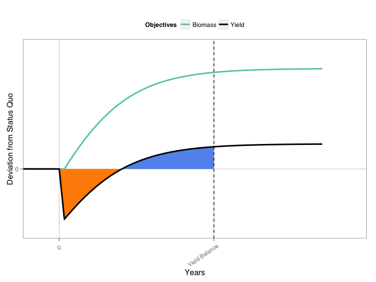

## Financial Mechanisms

We also analyze two potential financial mechanisms for offsetting short-term fishery losses stemming from the reserve; a loan system and a value added system. The total relative loss in yields experienced by the fishery for a given scenario *s* is

15. $O_{s} = -\sum^{T}_{t=0} min(0,Y_{s,t}-Y_{sq})$

Where *O<sub>s</sub>* is the amount of yield lost relative to the status quo (*sq*) over time period *T*. Under the loan strategy, a non-governmental organization, government, or private investor could provide a community with a loan to offset the initial losses from implementing a reserve, with a goal of being repaid by the future fishery benefits resulting from enhanced fishery productivity. The fishing community requests a loan totaling *O<sub>s</sub>*. The surplus available to pay the loan back over time *T* are equal to

16. $S_{s} = -\sum^{T}_{t=0} max(0,Y_{s,t}-Y_{q})$

Where *S<sub>s</sub>* is the total positive difference in yields (if any) for a given reserve scenario *s*,over what the fishery would have experienced under the status quo.

For a given loan interest rate *i* for a loan of duration *T*, the total loan payments are equal to

17. $C = Tp( \frac{\frac{i}{p}{O}}{1-(1+i)^{-Tp}})$

where *p* is the number of payments per year. Setting the time window of the loan to *T* of 10 years with *p* of 4 payments per year, we then use the *optim* package in *R* (R Core Team 2015) to estimate the highest interest rate *i* (%) that the community could afford in order to pay back a 10-year loan such that *C<sub>s,i</sub> <= S<sub>s</sub>*; meaning that the total loan payments must be less than or equal to the surplus generated by the reserve. The higher the maximum potential interest rate, the more viable the loan is. We break loans apart in to three categories: Interest rates greater than 15% are considered “commercial” (the high rate reflective of the risk in fisheries loans), 5%-15% “social investment” loans, provided by entities that expect a rate of return but may be less concerned with turning a profit, and philanthropy (<5%).

For the value increase scenario, we implicitly assume a status quo value of $1 per unit weight (though this is an arbitrary choice that does not influence the results). We then ask by what percent the value of the catch caught under a given scenario *s* would have to increase in order to completely offset the greatest loss of yields seen across all years

18. $P_{s} = 100(\frac{Y_{q}}{Y_{q}+min(Y_{s}-Y_{q})}-1))$

Reserves often face competing objectives between long-term conservation benefits and short-term economic benefits. This can be empirically illustrated by considering the cumulative biomass of fish in the water over time with a discount rate *r* of 0 (long-term conservation planner, $B_{r_{0}}$) vs. the net present benefits of the reserve over time with a discount rate *r* > 0 (in this case we consider 0.1, $Y_{r_{0.1}}$)). In order to consider the relative utility of a given reserve strategy *s* we assign a weighting parameter $\alpha$ that can take any value from 0 to 1, such that total utility *U* is calculated as

19. $U_{s} = \alpha(\frac{Y_{r_{0.1},s}}{\sum_{s}Y_{r_{0.1},s}}) + (1-\alpha)(\frac{B_{r_{0},s}}{\sum_{s}B_{r_{0},s}})$

This allows us to calculate utility focused solely on discounted fishery benefits ($\alpha$=1), long-term conservation benefits ($\alpha$=0), or any relative weighting in between). “Optimal” reserve policies are found by determining the combination of terminal reserve size, initial reserve size, and slope that maximizes utility *U*.

# Results

## Discount Rate

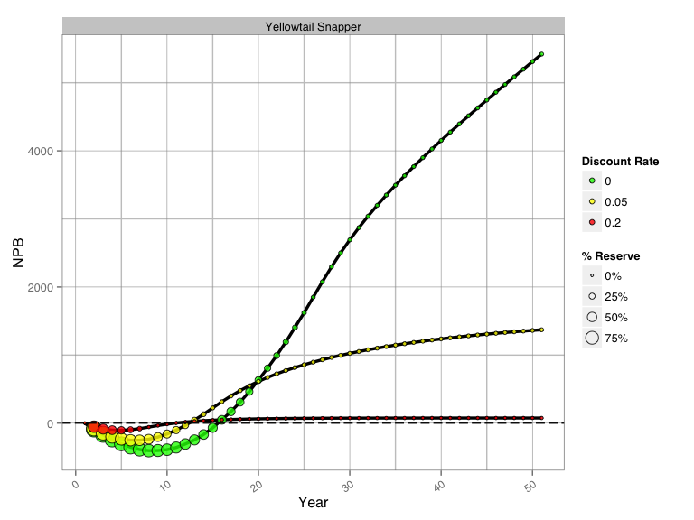

Example NPB trajectories under optimal reserve scenario under different discount rates for yellowtail snapper

## Solutions to Short-Term Losses

Clearly then the choice of discount rate greatly impacts a community’s perception of the ability of a reserve to provide benefits to their fisheries. For the remainder of this thought experiment we consider a discount rate of 0.2, to best reflect the type of artisanal fishery we are simulating. With this discount rate in mind, how does the final size of the reserve affect a community’s NPB? Under this thought experiment, the community picks one reserve size, ranging from 2.5% to 50% of the available habitat, and immediately implements it. We apply this procedure to each of the 6 species evaluated here, running over a 50 year time horizon.

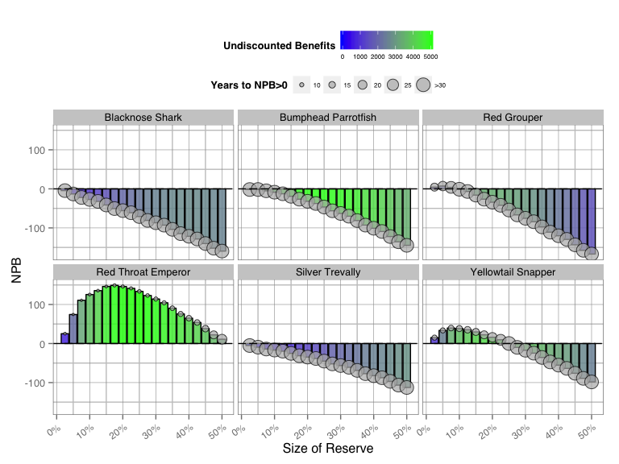

NPB with discount rate of 0.2 under possible terminal reserve sizes for each species

A single reserve size implemented today is not an ideal strategy for our hypothetical community decision maker for nearly any species evaluated here; the benefits simply accrue too far in the future, so our manager would rather maintain the overfished status quo than forgo yields today, even though the absolute future benefits are substantial. Brown et al. (2014) suggest that one solution to offsetting short-term losses may be to allow the reserve size to change over time. To that end, we consider the potential benefits to our community from allowing the reserve to change sizes over time. We set $\alpha$ to 0.9, meaning that 90% of the community’s utility comes from fishery benefits, but some consideration is made for long-term conservation outcomes.

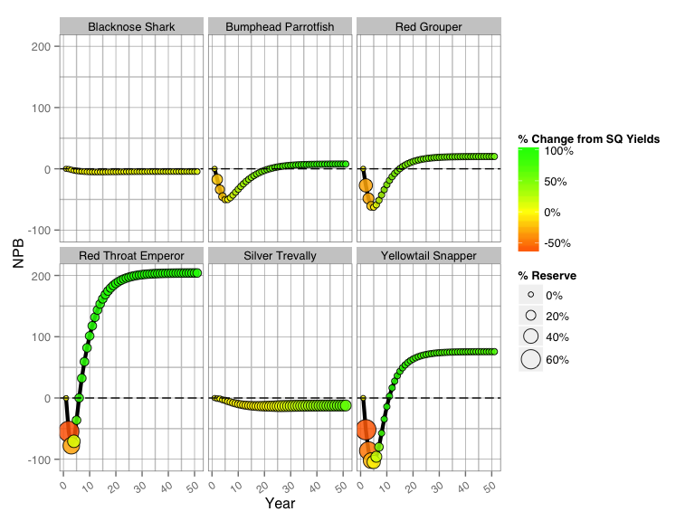

NPB trajectories under optimal reserve scenario. Size of circle represents % of ares in reserve, color the yield surplus in a given year

Our results so far provide three important points; 1) All the evaluated species in our hypothetical fishery are capable of benefiting in the long-term from a reserve but 2) those benefits take too long to arrive to be of value to a decision maker today and 3) optimal design can improve outcomes, but does not sufficiently accelerate the arrival of fishery benefits to make a reserve worthwhile to a fishing community. What if we then shift our focus from designing reserves to prevent fishing losses, but instead considered strategies to offset the reserve-induced losses that our results show are likely to occur for many species in our hypothetical fishery?

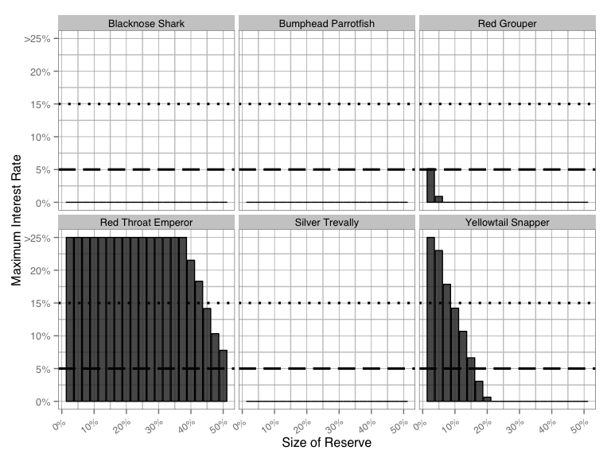

Maximum % interest rate payable by a fishery for each species across a range of terminal reserve sizes. Dashed line indicates break between philanthropic (<5%) and social investment (5%-15%) loans, above dotted line are commercial loans (>15%)

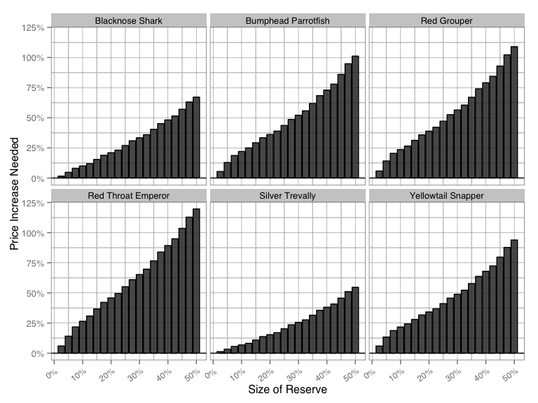

% Price increase required by a fishery for each species across a range of terminal reserve sizes

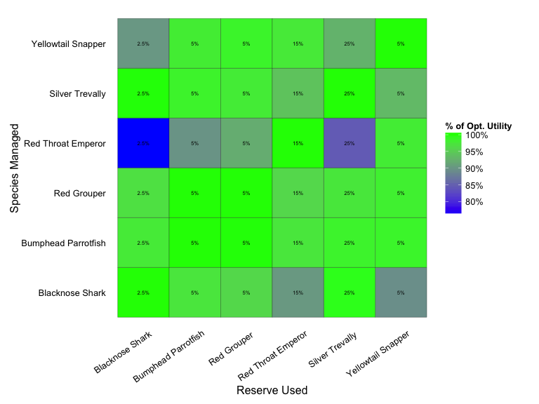

Comparison of NPB performance for each species using the other species optimal reserve

# Discussion

It has been well established that the ability of reserves to provide long-term benefits to fisheries is highly context dependent and uncertain. By simulating an overfished fishery with no capacity for additional management measure (such as size limits or effort restrictions), we ensure that our case-study fishery is in fact capable of being benefited by reserves in the long-term. However, we show that even in this context, short-term fishery benefits are far from certain. From the perspective of a community decision makers with a representative high discount rate, reserves of any substantial size do not provide benefits soon enough to be worth the short-term losses in fishery yields.

The specific results presented here are highly sensitive to particular choices in model parameters, such as discount rates, utility function, life history values, and fleet dynamics. As such, these findings are illustrative; the exact dynamics of the timing and magnitude of benefits may change greatly with different assumptions. A few key assumptions should be noted. First, we include no fishery management measures besides the reserve itself. Addition of tuning of fishing mortality rates or selectivity may dramatically change results. We felt that it was better to isolate the fishery effects of the reserve alone for the purposes of this paper, though further consideration of the best strategies for integrating reserves and other fishery management tools is warranted. We assume an initial fishery condition of 0.25 B/B<sub>MSY</sub>. The ability of reserves to provide short-term (or long-term) benefits scales with the degree of overfishing; a more overfished setting would result in greater short-term economic benefits from rebuilding, while starting the fishery at a higher biomass would reduce them.

We also use relatively simple fleet dynamics. We assume a fixed number of fishers that are concentrated outside the reserve following the implementation of a reserve. An alternative strategy would be to allow the fishing fleet to expand and contract in response to the profitability of fishing. Without management, we might assume then that any profit benefits generated by the reserve would be eventually offset by commensurate increases in fishing mortality.

Lastly, we do not directly incorporate source-sink dynamics, though the recruitment models used do allow species to have different reactions to the changes induced by the reserve. For example, we model red grouper density dependence at the regional level, mimicking regional spawning aggregations rather than allowing densities inside the reserve patches along to limit larval production of that species through patch-specific density dependence.

While these caveats can and should be revisited in assessing the effect of reserves on individual fisheries, our broader approach allows us to consider several broader conclusions.First, it is critical to consider the discount rate, or more broadly the ability and willingness of a community to forgo current yields for future benefits, and the timing of reserve-induced benefits in communicating the potential economic fishery impacts of a reserve. Our results show that even when long-term benefits are predicted to result from a reserve, it may take over a decade for the reserve to result in a net gain in fishing yields for the community. While this may be entirely acceptable to some communities, the discount rates reported by Johnson & Saunders (2014) and Curtis (2002) suggest that the magnitude of these eventual benefits would not be sufficient to offset the short-term losses required to achieve the gains. Presenting the evolution of net benefits over time as we have done allows researchers and decision makers to confront the potential economic impacts of a reserve, and determine whether a reserve of a particular size is likely to provide meaningful net benefits to a community.

From the perspective a community leader of an artisnal fishery, our results show that it is difficult for reserves alone to provide sufficient benefits quickly enough to offset the short-term economic losses induced by closing off fishing grounds. This result should not be taken as an indictment of reserves, but rather a call for clear analyses and communication of the real impacts of reserves to fishing communities. There are many documented benefits reserves can provide beyond fisheries, from providing conservation benefits and ecological resilience, to increased tourism potential. In addition, as in the overfished case modeled here, reserves can provide fishery benefits in the long-term.

It is imperative though that those engaged in the design and implementation of reserves carefully consider and communicate the short-term impacts of reserves on the economic well-being of affected fisheries. It is disingenuous to tell a community that a reserve will provide fishery benefits, but neglect to point out that those benefits may not accrue for over a decade. In addition, support and enforcement of a reserve may quickly dissipate if a reserve does not begin to provide net economic benefits to a community on the time scale fishermen were expecting. Discussing the timing and magnitude of benefits stemming from reserves allows stakeholders to directly confront the challenges, and consider what solutions may be on the table given their circumstances. Our results indicate that rather than focusing on eliminating short-term losses through careful design, or counting on future benefits to finance fishery improvement loans, more potential lies in helping communities increase the value of their catch to offset reserve induced losses.

Works Cited

Allison, G.W., Lubchenco, J. and Carr, M.H. (1998) Marine reserves are necessary but not sufficient for marine conservation. *Ecological Applications* **8**, S79–S92.

Babcock, E.A. and MacCall, A.D. (2011) How useful is the ratio of fish density outside versus inside no-take marine reserves as a metric for fishery management control rules? *Canadian journal of fisheries and aquatic sciences* **68**, 343–359.

Berkeley, S.A., Hixon, M.A., Larson, R.J. and Love, M.S. (2004) Fisheries sustainability via protection of age structure and spatial distribution of fish populations. *fisheries* **29**, 23–32.

Brown, C.J., Abdullah, S. and Mumby, P.J. (2014) Minimizing the short-term impacts of marine reserves on fisheries while meeting long-term goals for recovery. *Conservation Letters*, n/a–n/a.

Costello, C. and Polasky, S. (2008) Optimal harvesting of stochastic spatial resources. *Journal of Environmental Economics and Management* **56**, 1–18.

Cudney-Bueno, R., Lavín, M.F., Marinone, S.G., Raimondi, P.T. and Shaw, W.W. (2009) Rapid effects of marine reserves via larval dispersal. *PLoS ONE* **4**, e4140.

Curtis, J.A. (2002) Estimates of fishermen’s personal discount rate. *Applied Economics Letters* **9**, 775–778.

FAO (2011) *Review of the state of world marine fishery resources*, (FAO fisheries and aquaculture technical paper 569). Food; Agriculture Organization of the United Nations, Rome, Italy.

Fletcher, W.J., Kearney, R.E., Wise, B.S. and Nash, W.J. (2014) Large-scale expansion of no-take closures within the great barrier reef has not enhanced fishery production. *Ecological Applications*.

Gaines, S.D., White, C., Carr, M.H. and Palumbi, S.R. (2010) Designing marine reserve networks for both conservation and fisheries management. *Proceedings of the National Academy of Sciences* **107**, 18286–18293.

Gerber, L.R., Botsford, L.W., Hastings, A., Possingham, H.P., Gaines, S.D., Palumbi, S.R. and Andelman, S. (2003) Population models for marine reserve design: A retrospective and prospective synthesis. *Ecological Applications* **13**, 47–64.

Halpern, B.S., Gaines, S.D. and Warner, R.R. (2004) Confounding effects of the export of production and the displacement of fishing effort from marine reserves. *Ecological Applications* **14**, 1248–1256.

Hilborn, R., Micheli, F. and De Leo, G.A. (2006) Integrating marine protected areas with catch regulation. *Canadian Journal of Fisheries and Aquatic Sciences* **63**, 642–649.

Hilborn, R., Stokes, K., Maguire, J.-J., et al. (2004) When can marine reserves improve fisheries management? *Ocean & Coastal Management* **47**, 197–205.

Holland, D.S. and Brazee, R.J. (1996) Marine reserves for fisheries management. *Marine Resource Economics* **11**, 157–171.

Johannes, R.E. (2002) The renaissance of community-based marine resource management in oceania. *Annual Review of Ecology and Systematics* **33**, 317–340.

Johannes, R.E. (1978) Traditional marine conservation methods in oceania and their demise. *Annual Review of Ecology and Systematics* **9**, 349–364.

Johnson, A.E. and Saunders, D.K. (2014) Time preferences and the management of coral reef fisheries. *Ecological Economics* **100**, 130–139.

Kobayashi, D., Friedlander, A., Grimes, C., Nichols, R. and Zgliczynski, B. (2011) Bumphead parrotfish (bolbometopon muricatum) status review. NOAA-TM-NMFS-PIFSC-26. U.S. Department of Commerce.

Leigh, G.M., Williams, A.J., Begg, G.A., Gribble, N.A. and Whybird, O.J. (2006) Stock asessment of the queensland east coast red throat emperor (lethrinus miniatus) fishery. The State of Queensland, Department of Primary Industries; Fisheries, Queensland, Australia.

Lester, S., Halpern, B., Grorud-Colvert, K., et al. (2009) Biological effects within no-take marine reserves: A global synthesis. *Marine Ecology Progress Series* **384**, 33–46.

McClanahan, T.R. and Mangi, S. (2008) Spillover of exploitable fishes from a marine park and its effect on the adjacent fishery.

O’Hop, J., Murphy, M. and Chagaris, D. (2012) The 2012 stock assessment report for yellowtail snapper in the south atlantic and gulf of mexico. Fish; Wildlife Conservation Commission, St. Petersburg, Florida.

Pelc, R.A., Warner, R.R., Gaines, S.D. and Paris, C.B. (2010) Detecting larval export from marine reserves. *Proceedings of the National Academy of Sciences* **107**, 18266–18271.

R Core Team (2015) R: A language and environment for statistical computing.

Rassweiler, A., Costello, C. and Siegel, D.A. (2012) Marine protected areas and the value of spatially optimized fishery management. *Proceedings of the National Academy of Sciences* **109**, 11884–11889.

Roberts, C.M. and Polunin, N.V.C. (1991) Are marine reserves effective in management of reef fisheries? *Reviews in Fish Biology and Fisheries* **1**, 65–91.

Rowling, K. and Raines, L. (2000) Description of the biology and an assessment of the fishery for silver trevally pseudocaranx dentex off new south wales. NSW Fisheries Research Institute.

Sala, E., Costello, C., Dougherty, D., et al. (2013) A general business model for marine reserves. *PLoS ONE* **8**, e58799.

Sanchirico, J.N. and Wilen, J.E. (2001) A bioeconomic model of marine reserve creation. *Journal of Environmental Economics and Management* **42**, 257–276.

Sanchirico, J.N., Malvadkar, U., Hastings, A. and Wilen, J.E. (2006) When are no-take zones an economically optimal fishery management strategy? *Ecological Applications* **16**, 1643–1659.

SEDAR (2011) HMS gulf of mexico blacknose shark. 21. Southeast Data, Assessment & Review.

SEDAR (2009) Stock assessment of red grouper in the gulf of mexico - SEDAR update assessment. Miami, FL.

Smith, M.D. and Wilen, J.E. (2003) Economic impacts of marine reserves: The importance of spatial behavior. *Journal of Environmental Economics and Management* **46**, 183–206.

Stefansson, G. and Rosenberg, A.A. (2005) Combining control measures for more effective management of fisheries under uncertainty: Quotas, effort limitation and protected areas. *Philosophical Transactions of the Royal Society B: Biological Sciences* **360**, 133–146.

Teh, L.S.L., Teh, L.C.L. and Rashid Sumaila, U. (2014) Time preference of small-scale fishers in open access and traditionally managed reef fisheries. *Marine Policy* **44**, 222–231.

White, C., Kendall, B.E., Gaines, S., Siegel, D.A. and Costello, C. (2008) Marine reserve effects on fishery profit. *Ecology Letters* **11**, 370–379.

Wilson, J.R., Valencia, S.R., Kay, M.C. and Lenihan, H.S. (2013) Integration of no-take marine reserves in the assessment of data-limited fisheries. *Conservation Letters*, n/a–n/a.